# Cardio fitness project:

*Submitted by: Vijaykumar Sathyamurthi* *Submitted on: 07/29/2021*

## This section of the code does the following:

- Import necessary packages

```python
#Import NumPy
import numpy as np
#Import Pandas to manage dataframes
import pandas as pd
#Plot dataset to understand characteristics
#Import seaborn
import seaborn as sn
#Import Matplotlib
import matplotlib.pyplot as plt
import matplotlib.gridspec as gridspec
import os
#Installation step
#!pip install pandas-profiling
#or
import sys
#!{sys.executable} -m pip install pandas-profiling
import pandas_profiling
# Improve graph background
sn.set(color_codes=True)
# tells python to actually display the graphs
%matplotlib inline
```

## This section of the code does the following:

- Run Pandas profiling
- Import data and review the shape of the data,
- Find column headers,
- Unique product models

```python
#Read file into DataFrame
df = pd.read_csv('CardioGoodFitness.csv')
print(df)

#Perform profiling in Pandas
pandas_profiling.ProfileReport(df)
pandas_profiling.ProfileReport(df).to_file("Pandas profiling report.html")

#Obtain shape of the DataFrame
shape = df.shape
print('Shape of data frame (rows x columns) :', shape)
print('Number of rows :', shape[0])
print('Number of columns :', shape[1])

#Print column headers to understand the different categories
print('\nCOLUMN HEADERS:')
for col in df.columns:
    print(col)

print('\n The datatypes in the dataset are: ',df.dtypes)
#Determine number of unique products/models
prd=list(df['Product'].unique())
print('The product mix consists of the following ', len(prd),' models: ' ,prd)
```

```
    Product  Age  Gender  Education MaritalStatus  Usage  Fitness  Income  \
0     TM195   18    Male         14        Single      3        4   29562
1     TM195   19    Male         15        Single      2        3   31836
2     TM195   19  Female         14     Partnered      4        3   30699
3     TM195   19    Male         12        Single      3        3   32973
4     TM195   20    Male         13     Partnered      4        2   35247
..      ...  ...     ...        ...           ...    ...      ...     ...
175   TM798   40    Male         21        Single      6        5   83416
176   TM798   42    Male         18        Single      5        4   89641
177   TM798   45    Male         16        Single      5        5   90886
178   TM798   47    Male         18     Partnered      4        5  104581
179   TM798   48    Male         18     Partnered      4        5   95508

     Miles
0      112
1       75
2       66
3       85
4       47
..     ...
175    200
176    200
177    160
178    120
179    180

[180 rows x 9 columns]
```

```
Shape of data frame (rows x columns) : (180, 9)
Number of rows : 180
Number of columns : 9

COLUMN HEADERS:
Product
Age
Gender
Education
MaritalStatus
Usage
Fitness
Income
Miles

 The datatypes in the dataset are:  Product          object
Age               int64
Gender           object
Education         int64
MaritalStatus    object
Usage             int64
Fitness           int64
Income            int64
Miles             int64
dtype: object
The product mix consists of the following  3  models:  ['TM195', 'TM498', 'TM798']
```

### Observations:

- The data contains 180 rows and nine columns,
- Product, gender, and marital status are of object data-type,
- All other variables are of integer data type,
- The product mix consists of three unique models.

## This section of the code checks the data for missing values

```python
#Check if there are any missing values in the dataset - loop through the columns in dataframe and check each column
for column in df:
    # Select column contents by column
    # name using [] operator
    columnSeriesObj = df[column]
    if (columnSeriesObj.isnull().sum()>0):
        print('Column Name : ', column, ' has blank cells')
    else:
        print('Column Name : ', column, ' has no blank cells')
```

```
Column Name :  Product  has no blank cells
Column Name :  Age  has no blank cells
Column Name :  Gender  has no blank cells
Column Name :  Education  has no blank cells
Column Name :  MaritalStatus  has no blank cells
Column Name :  Usage  has no blank cells
Column Name :  Fitness  has no blank cells
Column Name :  Income  has no blank cells
Column Name :  Miles  has no blank cells
```

### Observations:

- There are no blank cells in any of the columns.

## Perform Exploratory Data Analysis (EDA):

- Print descriptive statistics

```python
df.describe().round(decimals=2)
```

|  | Age | Education | Usage | Fitness | Income | Miles |
| --- | --- | --- | --- | --- | --- | --- |
| count | 180.00 | 180.00 | 180.00 | 180.00 | 180.00 | 180.00 |
| mean | 28.79 | 15.57 | 3.46 | 3.31 | 53719.58 | 103.19 |
| std | 6.94 | 1.62 | 1.08 | 0.96 | 16506.68 | 51.86 |
| min | 18.00 | 12.00 | 2.00 | 1.00 | 29562.00 | 21.00 |
| 25% | 24.00 | 14.00 | 3.00 | 3.00 | 44058.75 | 66.00 |
| 50% | 26.00 | 16.00 | 3.00 | 3.00 | 50596.50 | 94.00 |
| 75% | 33.00 | 16.00 | 4.00 | 4.00 | 58668.00 | 114.75 |
| max | 50.00 | 21.00 | 7.00 | 5.00 | 104581.00 | 360.00 |

```python
df.loc[df.Product=="TM195"].describe().round(decimals=2)
```

|  | Age | Education | Usage | Fitness | Income | Miles |
| --- | --- | --- | --- | --- | --- | --- |
| count | 80.00 | 80.00 | 80.00 | 80.00 | 80.00 | 80.00 |
| mean | 28.55 | 15.04 | 3.09 | 2.96 | 46418.02 | 82.79 |
| std | 7.22 | 1.22 | 0.78 | 0.66 | 9075.78 | 28.87 |
| min | 18.00 | 12.00 | 2.00 | 1.00 | 29562.00 | 38.00 |
| 25% | 23.00 | 14.00 | 3.00 | 3.00 | 38658.00 | 66.00 |
| 50% | 26.00 | 16.00 | 3.00 | 3.00 | 46617.00 | 85.00 |
| 75% | 33.00 | 16.00 | 4.00 | 3.00 | 53439.00 | 94.00 |
| max | 50.00 | 18.00 | 5.00 | 5.00 | 68220.00 | 188.00 |

```python
df.loc[df.Product=="TM498"].describe().round(decimals=2)
```

|  | Age | Education | Usage | Fitness | Income | Miles |
| --- | --- | --- | --- | --- | --- | --- |
| count | 60.00 | 60.00 | 60.00 | 60.00 | 60.00 | 60.00 |
| mean | 28.90 | 15.12 | 3.07 | 2.90 | 48973.65 | 87.93 |
| std | 6.65 | 1.22 | 0.80 | 0.63 | 8653.99 | 33.26 |
| min | 19.00 | 12.00 | 2.00 | 1.00 | 31836.00 | 21.00 |
| 25% | 24.00 | 14.00 | 3.00 | 3.00 | 44911.50 | 64.00 |
| 50% | 26.00 | 16.00 | 3.00 | 3.00 | 49459.50 | 85.00 |
| 75% | 33.25 | 16.00 | 3.25 | 3.00 | 53439.00 | 106.00 |
| max | 48.00 | 18.00 | 5.00 | 4.00 | 67083.00 | 212.00 |

```python
df.loc[df.Product=="TM798"].describe().round(decimals=2)
```

|  | Age | Education | Usage | Fitness | Income | Miles |
| --- | --- | --- | --- | --- | --- | --- |
| count | 40.00 | 40.00 | 40.00 | 40.00 | 40.00 | 40.00 |
| mean | 29.10 | 17.32 | 4.78 | 4.62 | 75441.58 | 166.90 |
| std | 6.97 | 1.64 | 0.95 | 0.67 | 18505.84 | 60.07 |
| min | 22.00 | 14.00 | 3.00 | 3.00 | 48556.00 | 80.00 |
| 25% | 24.75 | 16.00 | 4.00 | 4.00 | 58204.75 | 120.00 |
| 50% | 27.00 | 18.00 | 5.00 | 5.00 | 76568.50 | 160.00 |
| 75% | 30.25 | 18.00 | 5.00 | 5.00 | 90886.00 | 200.00 |
| max | 48.00 | 21.00 | 7.00 | 5.00 | 104581.00 | 360.00 |

### Observations:

The typical customer profile appears to be as follows based on the statistics above:

- The average customer age is approximately 28.7 years with a standard deviation of around 6.94 years,
- The youngest customer is 18 years and the oldest is 50 years old,
- The median age is 26 years,
- The average education level of a customer is approximately 16 years with a standard deviation of 1.6 years,
- The average customer income level is 53720 with a high standard deviation of approximately 16507,
- The average usage level is 3.45 with a standard deviation of 1.085,
- The average fitness level is 3.31 with a standard deviation of 0.96,
- The average miles per user is 103 but shows a considerable variation with a std. deviation of 51.86
- When split by product type, there appears to be little difference in the income level, age, education, usage, and fitness levels (average) for TM195 and TM498.

## Perform EDA - Univariate analysis:

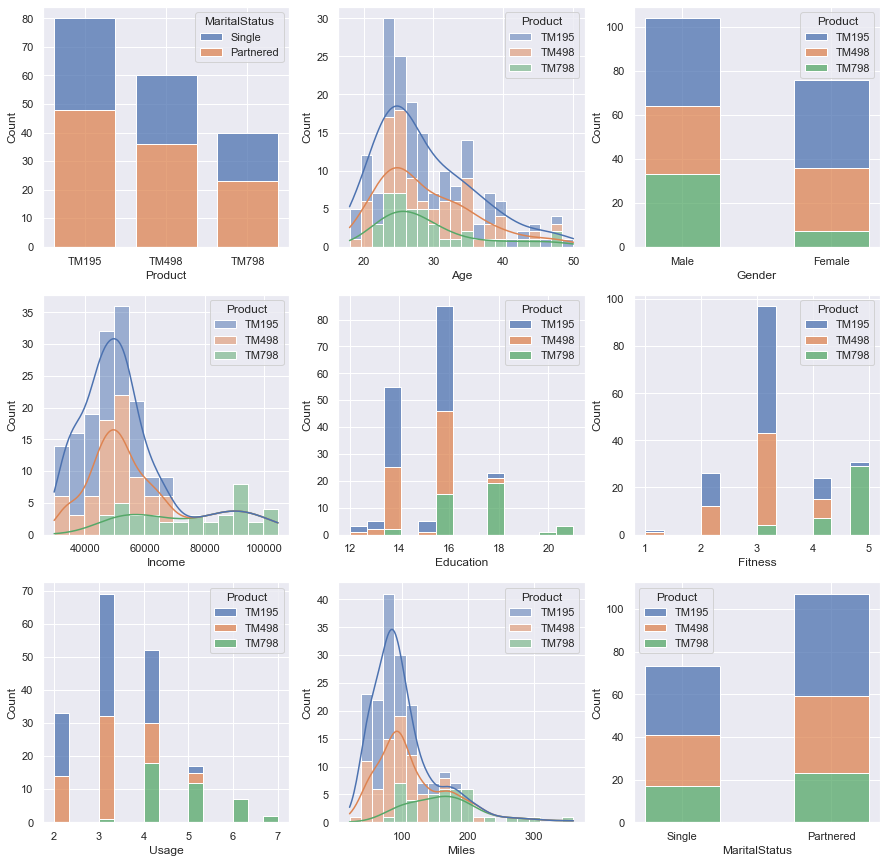

```python
#Exploratory data analysis - Univariate analysis
fig, axs = plt.subplots(ncols=3,nrows=3,sharex=False,clear=True,figsize=(15,15))
sn.histplot(x="Product",data=df, ax=axs[0][0],hue="MaritalStatus",multiple="stack",shrink=0.75);
sn.histplot(x="Age",data=df, ax=axs[0][1],bins=20,hue="Product",multiple="stack", kde="True");
sn.histplot(x="Gender",data=df, ax=axs[0][2],hue="Product",multiple="stack",shrink=0.5);
sn.histplot(x="Income",data=df, ax=axs[1][0],hue="Product",multiple="stack",kde="True");
sn.histplot(x="Education",data=df, ax=axs[1][1],hue="Product",multiple="stack");
sn.histplot(x="Fitness",data=df, ax=axs[1][2],hue="Product",multiple="stack");
sn.histplot(x="Usage",data=df, ax=axs[2][0],hue="Product",multiple="stack");
sn.histplot(x="Miles",data=df, ax=axs[2][1],hue="Product",multiple="stack",kde="True");
sn.histplot(x="MaritalStatus",data=df, ax=axs[2][2],hue="Product",multiple="stack",shrink=0.5);
```

### Observations:

- There are three products' that attempt to fit the "Good-Better-Best" product mix,
- TM195 sells the most, followed by TM498, and TM798,
- There is little differentiation between TM195 and TM498 in terms of the target group by:
  - age,
  - income,
  - education,
  - miles,
  - and usage.
- People with higher income levels (>45000 at least), education (> 14 years), and fitness levels prefer TM798
- Most people who prefere the TM798 tend to be males, with higher income levels, and education levels of 16 - 18 years or greater, with a typical fitness level of 5 and usage at 4 or greater.
- Most customers are partnered.

## Univariate analysis - histogram plots by each column of data

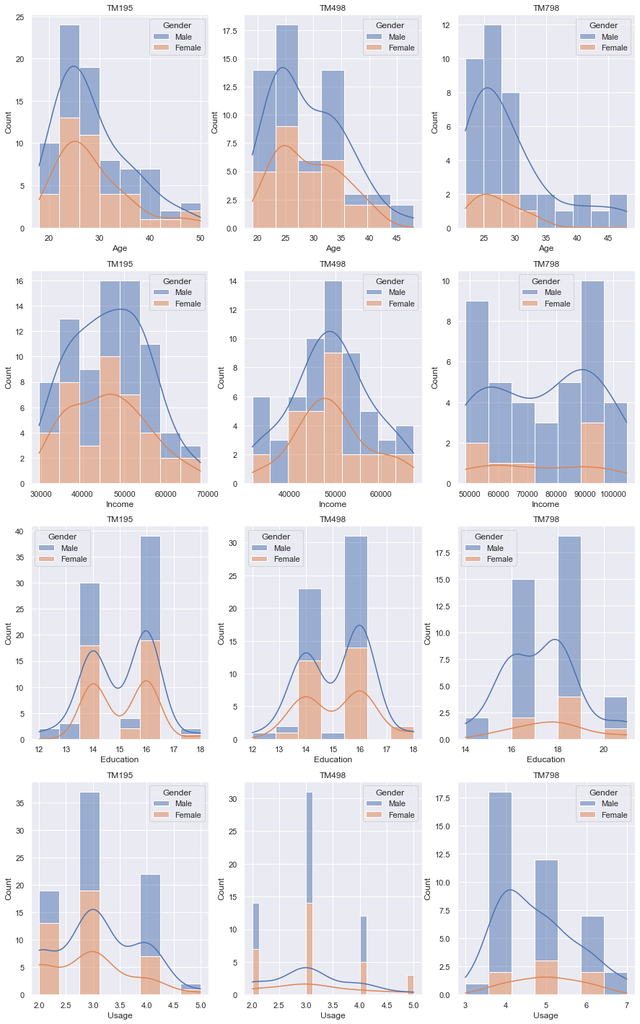

```python
fig, axs = plt.subplots(ncols=3,nrows=4,sharex=False,clear=True,figsize=(15,25))
sn.histplot(x="Age",data=df.loc[df.Product == "TM195"],ax=axs[0][0],hue="Gender",multiple="stack",kde=True).set(title="TM195");
sn.histplot(x="Age",data=df.loc[df.Product == "TM498"],ax=axs[0][1],hue="Gender",multiple="stack",kde=True).set(title="TM498");
sn.histplot(x="Age",data=df.loc[df.Product == "TM798"],ax=axs[0][2],hue="Gender",multiple="stack",kde=True).set(title="TM798");
sn.histplot(x="Income",data=df.loc[df.Product == "TM195"],ax=axs[1][0],hue="Gender",multiple="stack",kde=True).set(title="TM195");
sn.histplot(x="Income",data=df.loc[df.Product == "TM498"],ax=axs[1][1],hue="Gender",multiple="stack",kde=True).set(title="TM498");
sn.histplot(x="Income",data=df.loc[df.Product == "TM798"],ax=axs[1][2],hue="Gender",multiple="stack",kde=True).set(title="TM798");
sn.histplot(x="Education",data=df.loc[df.Product == "TM195"],ax=axs[2][0],hue="Gender",multiple="stack",kde=True).set(title="TM195");
sn.histplot(x="Education",data=df.loc[df.Product == "TM498"],ax=axs[2][1],hue="Gender",multiple="stack",kde=True).set(title="TM498");
sn.histplot(x="Education",data=df.loc[df.Product == "TM798"],ax=axs[2][2],hue="Gender",multiple="stack",kde=True).set(title="TM798");
sn.histplot(x="Usage",data=df.loc[df.Product == "TM195"],ax=axs[3][0],hue="Gender",multiple="stack",kde=True).set(title="TM195");
sn.histplot(x="Usage",data=df.loc[df.Product == "TM498"],ax=axs[3][1],hue="Gender",multiple="stack",kde=True).set(title="TM498");
sn.histplot(x="Usage",data=df.loc[df.Product == "TM798"],ax=axs[3][2],hue="Gender",multiple="stack",kde=True).set(title="TM798");
```

### Observations:

- Age
  - TM195 is preferred by people between 20 and 30 years of age,
  - Females between ~ 23 - 37 years old tend to prefer the TM195 more than males,
  - TM498 is preferred by people between 20 and 35 years of age,
  - Female customers of the TM498 between 23 and 32 years and between 35 and 45 years outnumber the males,
  - TM798 is bought by people between 20 and 30 years old, and is preferred by males,
- Income
  - People with incomes between 30000 and 54000 prefer the TM195
  - TM498 is preferred by people with income between 44000 and 54000
  - TM798 is preferred generally by men with incomes between 50000 and 60000, and strongly by males with incomes between 80000 and 95000
- Education and Usage
  - People with education levels between 16 and 20 years and usage at 4 or above prefer TM798
  - People with education levels of 14 and 16 years and usage greater than 2 prefer the TM195/TM498

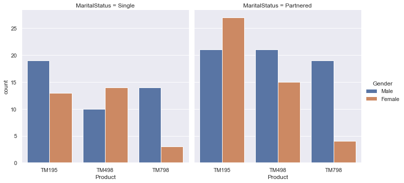

```python
#Identify which Model sells most relative to gender and marital status
sn.catplot(x="Product",
               hue="Gender",
               col="MaritalStatus",
               data=df,
               kind="count");
```

### Observations:

- Single
  - Single males prefer the TM195 or TM798 over TM498,
  - Single females prefer the TM498 over single males and slightly more than TM195.
- Partnered
  - Partnered males appear to prefer the TM195 and TM 498 equally, closely followed by the TM798,
  - Partnered females prefer the TM195 strongly, followed by TM498 and lastly followed by TM798

## Perform Bi-/Multi-variate EDA analysis:

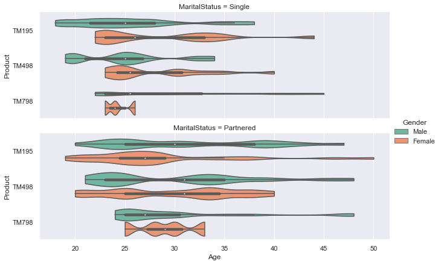

```python
sn.catplot(x="Age", y="Product",hue="Gender", row="MaritalStatus",
          data=df[df.Product.notnull()],
          orient="h", height=3, aspect=3, palette="Set2",
          kind="violin", dodge=True, cut=0, bw=.2);
```

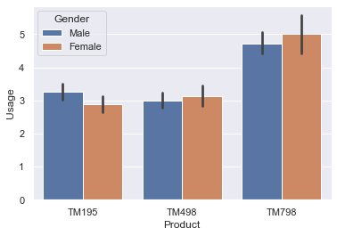

```python
sn.barplot(data = df, x='Product',y='Usage', hue=df['Gender']);
```

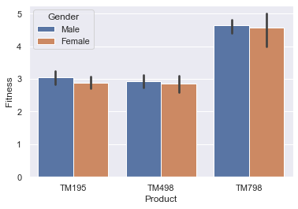

```python
sn.barplot(data = df, x='Product',y='Fitness', hue=df['Gender']);
```

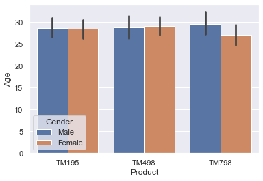

```python
sn.barplot(data = df, x='Product',y='Age', hue=df['Gender']);
```

### Observations:

- Little difference by age or gender in customer profiles of TM195 and TM498 with respect to fitness usage and age.
- Customers with higher fitness and usage levels prefer the TM798.

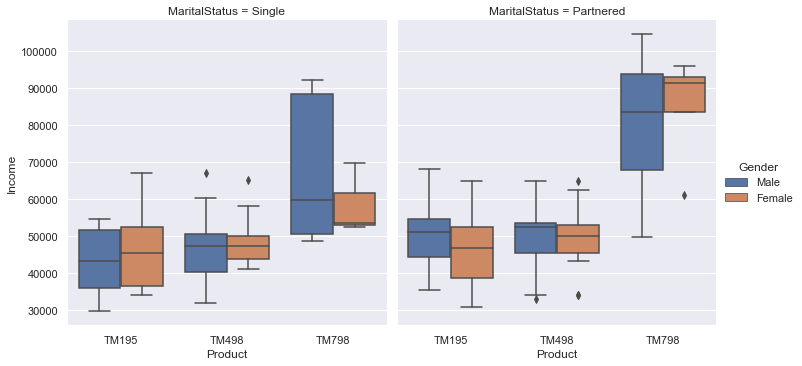

```python
sn.catplot(x="Product",
               y = "Income",
               hue="Gender",
               col="MaritalStatus",
               data=df,
               kind="box");
```

### Observations:

- There is little difference in customer income levels regardless of marital status between TM195 and TM 498
- TM798 appears to be clearly targetting higher income users especially amongst those who are partnered.

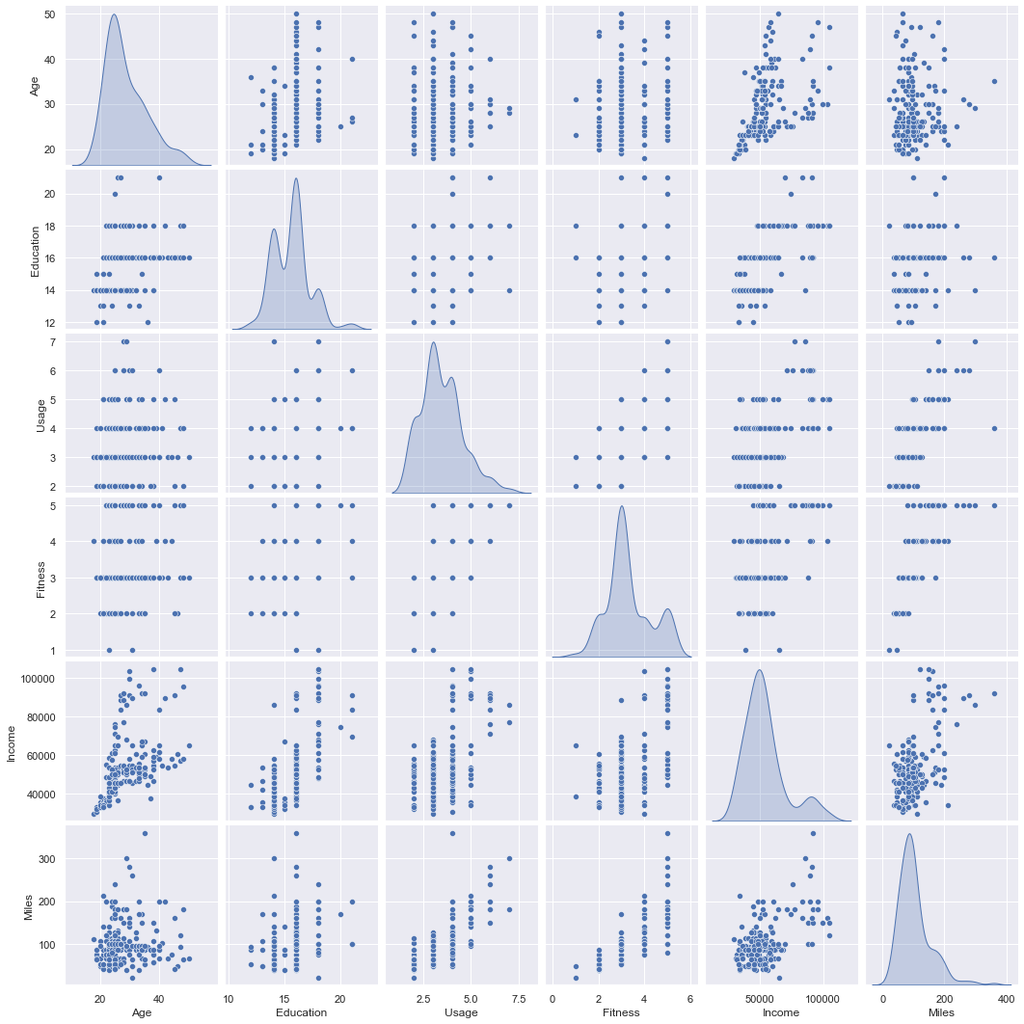

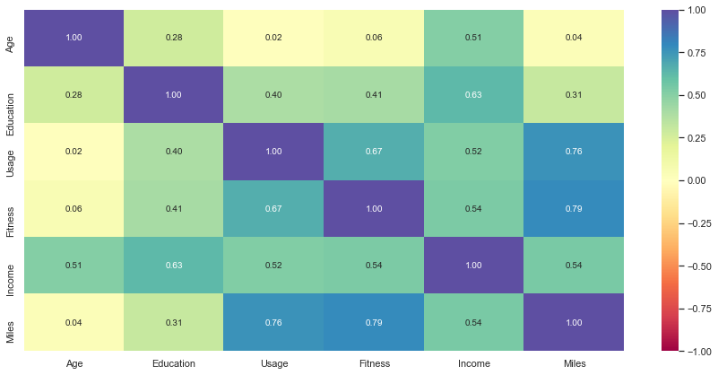

```python
sn.pairplot(df, diag_kind="kde")
correlation = df.corr() # create a 2-D Matrix with correlation plots
correlation
plt.figure(figsize=(15, 7))
sn.heatmap(correlation, annot=True, vmin=-1, vmax=1, fmt=".2f", cmap="Spectral")
plt.show()
```

### Observations:

- There is a strong correlation between Usage and miles, Usage and fitness, and, fitness and miles.
- There is a good correlation between education and income and some correlation between age and income.
- Perhaps it would be good to consider replacing usage, fitness, and miles data by some sort of a combined metric.
- There is a fair correlation between usage/fitness and income as well, and miles and income.

## Conclusions:

- TM195
  - It appears to be the low end of the product range and targets users with an average income of ~ 46418, and an income range between 30000 and 50000
  - Generally preferred by people between 20 and 30 years of age.
  - Single males tend to prefer TM195 over the other models.
  - Partnered females strongly prefer the TM195 and partnered males prefer it at nearly the same level as they prefer the TM498.
- TM498
  - This appears to be the mid-range or 'better' category product but appears to target the same group as the TM195.
  - Ideally, this product would target consumers with average fitness/usage levels of around 3.7 or 3.8 and income levels on average of about 60000 (between the average levels of TM195 and TM798). However, it fails to do this.
  - The product appeals to single females. This should be explored further by looking at the features relative to TM195 and understanding the Voice of the Customer (VOC) better.
- TM798
  - This product has the least sales volume and attempts to target the highest income, education, fitness, miles, and usage levels amongst users.
  - The opportunity to extend the uptake of this product amongst 30 - 40 year olds, and amongst females in particular needs to be explored as females do not seem to prefer this product for some reason.
  - The possibility of extending the sales of this product to people with lower fitness, usage, and mileage profiles needs to be investigated.

```python
!jupyter nbconvert --to html your_notebook_name.ipynb
```